# Practical Machine Learning Course Project

Jessica Dyer

2/21/2021

# Executive summary

To the people grading this assignment: I spent many hours trying to get these models to run on my computer and did not have very much luck. In the end, I’ve commented out models that wouldn’t build (random forests) and kept the only two that I could get to compile (decision trees & boosting). Ultimately, I’m sure this is incorrect, but I cannot spent more time on this when I know my computer will not support this assignment. I learned a lot and hope to figure out a more computationally inexpensive way to do this type of work in the future.

# Introduction

[Link to Github Pages](https://jessica-dyer.github.io/practicalmachinelearning/)

Using devices such as Jawbone Up, Nike FuelBand, and Fitbit it is now possible to collect a large amount of data about personal activity relatively inexpensively. These type of devices are part of the quantified self movement – a group of enthusiasts who take measurements about themselves regularly to improve their health, to find patterns in their behavior, or because they are tech geeks. One thing that people regularly do is quantify how much of a particular activity they do, but they rarely quantify how well they do it. In this project, our goal is to use data from accelerometers on the belt, forearm, arm, and dumbell of 6 participants. They were asked to perform barbell lifts correctly and incorrectly in 5 different ways. More information is available from the website [here](http://groupware.les.inf.puc-rio.br/har), (see the section on the Weight Lifting Exercise Dataset).

# Methods

1. Load data
2. set seed and split data
3. Google which accelerometer data best predicts quality of movement?

```r
# SPLIT THE DATA INTO TRAINING AND TESTING USING `createDataPartition`
set.seed(43929)
in_train <- createDataPartition(y = train$classe,
                                p = .70,
                                list = FALSE)

training <- train[in_train, ]
testing <- train[-in_train, ]
```

## Removing coviariates

Some variables have no variability. This dataset has 160 variables, so in order to quickly remove the variables with no variability, we looked at which variables is a near zero variance predictor. We will remove these variables from our training dataset. These will need to be removed from the testing dataset as well.

```r
nzv <- nearZeroVar(training, saveMetrics = TRUE)

nzv_vars <-
  nzv %>% filter(nzv == "TRUE")

remove_vars <- row.names(nzv_vars)
```

```r
training <- training[, !names(training) %in% remove_vars]
```

## Examine missingness

```r
n_var_miss(training)
```

```
## [1] 45
```

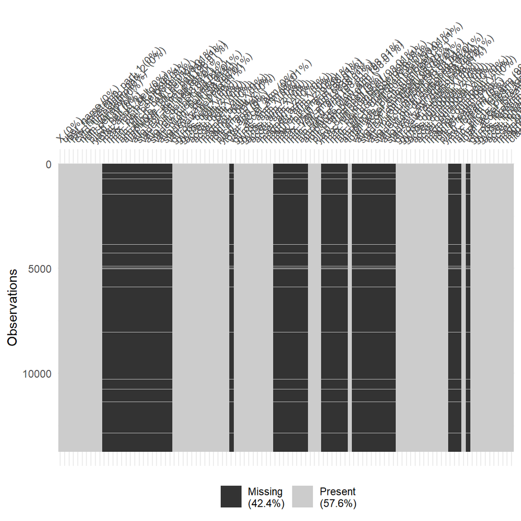

```r
vis_miss(training,
         warn_large_data = FALSE)
```

```r
missing <- gg_miss_var(training)
df <- data.frame(missing$data$variable, missing$data$n_miss)
df <- df %>%
  filter(missing.data.n_miss > 0)
remove_vars2 <- df$missing.data.variable

training <-
  training %>%
  select(!(remove_vars2))
```

- There are 45 variables in the training dataset with close to 100% missingness.

## Remove variables from cross validation and test datasets

```r
remove <- c(remove_vars, remove_vars2)

testing <- testing[, !names(testing) %in% remove]
test <- test[, !names(test) %in% remove]
```

## Coerce all data to same type

```r
for (i in 1:length(testing) ) {
        for(j in 1:length(training)) {
        if( length( grep(names(training[i]), names(testing)[j]) ) ==1)  {
            class(testing[j]) <- class(training[i])
        }
    }
}
```

# Model building

## Model 1: Decision tree

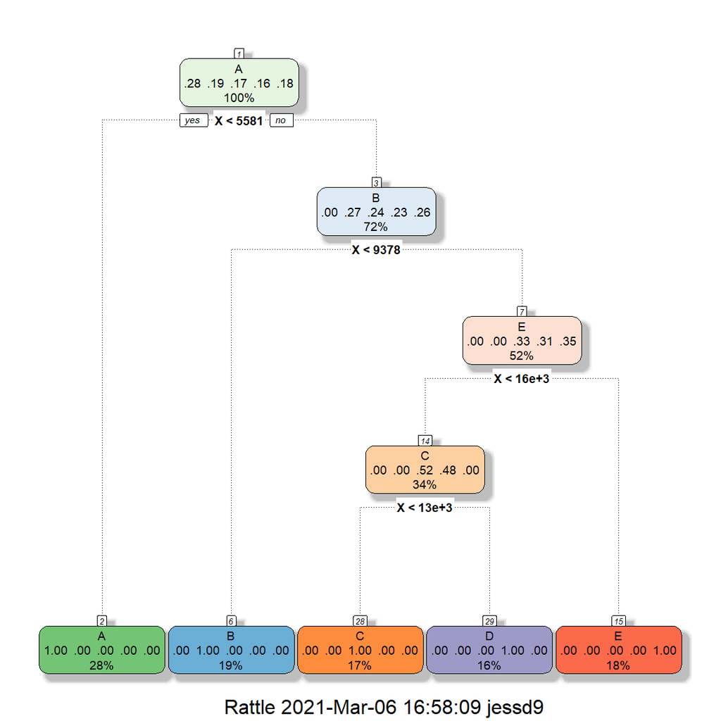

```r
set.seed(2938)

mod_fit_1 <- rpart(classe ~ ., data=training, method="class")

fancyRpartPlot(mod_fit_1)
```

## Model 2: Stochastic Gradient Boosting (gbm)

```r
cl <- makeCluster(detectCores())
registerDoParallel(cl)
set.seed(2938)
mod_fit_2 <- train(classe ~ ., method="gbm", data=training, verbose=FALSE)
```

## Model 3: Random forest

My machine cannot run this model, it keeps crashing. Therefore, I cannot include it here.

```r
# cl <- makeCluster(detectCores())
# registerDoParallel(cl)
# set.seed(2938)
# mod_fit_3 <- train(classe ~ ., data=training, method="rf", prox=TRUE)
```

# Results

```r
predictions_1 <- predict(mod_fit_1, testing, type = "class")
p1 <- confusionMatrix(predictions_1, testing$classe)

predictions_2 <- predict(mod_fit_2, testing)
p2 <- confusionMatrix(predictions_2, testing$classe)

# predictions_3 <- predict(mod_fit_3, testing)
# p3 <- confusionMatrix(predictions_3, testing$classe)

predict_1 <- p1$overall
predict_2 <- p2$overall
# predict_3 <- p3$overall

predict <- round(data.frame(predict_1, predict_2), 4)
variables <- names(predict_1)
predict <- data.frame(variables, predict)

names(predict) <- c("Statistic", "Decision trees", "Stochastic gradient Boosting")

predict %>%
  gt() %>%
  tab_header(
    title = "Comparison of two prediction models"
  )
```

Comparison of two prediction models

| Statistic | Decision trees | Stochastic gradient Boosting |
| --- | --- | --- |
| Accuracy | 0.9998 | 0.9998 |
| Kappa | 0.9998 | 0.9998 |
| AccuracyLower | 0.9991 | 0.9991 |
| AccuracyUpper | 1.0000 | 1.0000 |
| AccuracyNull | 0.2845 | 0.2845 |
| AccuracyPValue | 0.0000 | 0.0000 |
| McnemarPValue | NaN | NaN |

# Test

I selected the model created using decision trees because it was the easiest model to run on my machine.

```r
final <- predict(mod_fit_1, test)
final
```

```
##    A B C D E
## 1  1 0 0 0 0
## 2  1 0 0 0 0
## 3  1 0 0 0 0
## 4  1 0 0 0 0
## 5  1 0 0 0 0
## 6  1 0 0 0 0
## 7  1 0 0 0 0
## 8  1 0 0 0 0
## 9  1 0 0 0 0
## 10 1 0 0 0 0
## 11 1 0 0 0 0
## 12 1 0 0 0 0
## 13 1 0 0 0 0
## 14 1 0 0 0 0
## 15 1 0 0 0 0
## 16 1 0 0 0 0
## 17 1 0 0 0 0
## 18 1 0 0 0 0
## 19 1 0 0 0 0
## 20 1 0 0 0 0
```

# Conclusion

This assignment was very difficult due to my computer’s inability to run these models. Therefore, I’m certain that these results are incorrect. However, I just wanted to turn something in so I could complete this course. I also do not know why each of the models I did get to run have identical results.